# OHI-Northeast: Economies

# Methods

The economies score, $x_{eco}'$, is calculated for each region using the following equation;

$$x_{eco}' = \frac{\frac{E_{i}}{E_{r}}}{USGDP_{i}}$$

where $E_{i}$ is the total GDP in year *i*, and $E_{r}$ is the mean annual GDP for the previous year. The growth rate, ${\frac{E_{i}}{E_{r}}}$, is compared to the national average GDP growth rate for year *i*.

## Calculate annual growth rate

The annual GDP growth rate is calculated by comparing every year’s GDP total to the previous year.

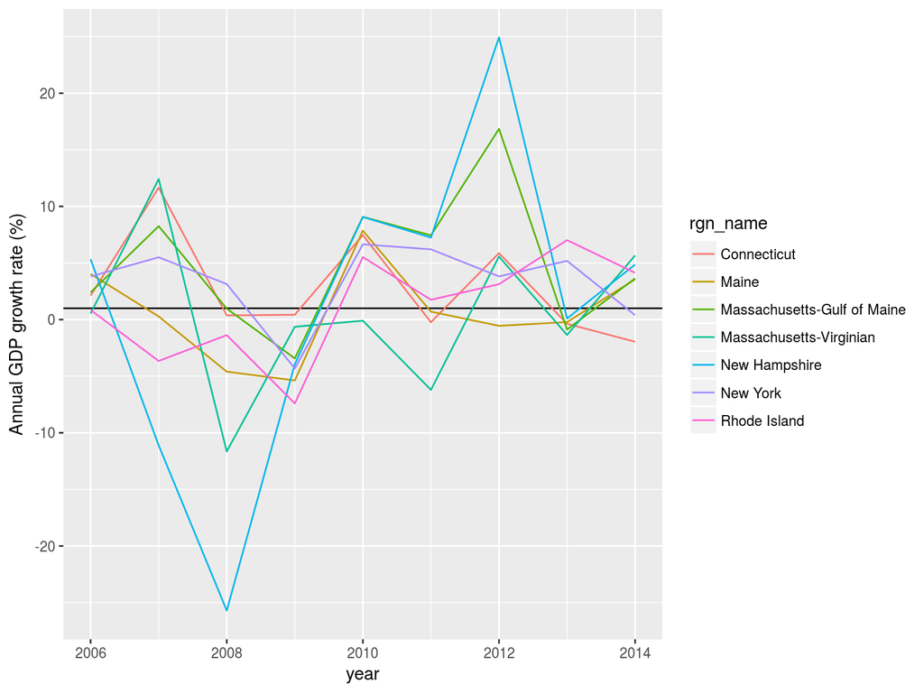

```r
gdp_cst_ref <- coast_gdp %>%
  arrange(year) %>%
  group_by(rgn_id) %>%
  mutate(coast_gdp_1yr = rollapply(rgn_gdp, 1, FUN=mean, align = "right", na.rm=F, partial = T),
         coast_gdp_prev_1yr = lag(coast_gdp_1yr, n = 1)) %>%
  select(state, year, rgn_id, rgn_name, ref = coast_gdp_prev_1yr)

#combining the coastal GDP data and calculate the change
  cst_gdp <- coast_gdp %>%
    left_join(gdp_cst_ref) %>%    #join with the reference point data
    filter(!is.na(ref)) %>%       #remove years with NA for wages (same as removing years pre-2010)
    mutate(cst_chg = (rgn_gdp/ref))

  ggplot(cst_gdp, aes(x = year, y = (cst_chg-1)*100, color = rgn_name)) +
    geom_hline(yintercept = 1) +
    geom_line() +
    ylab("Annual GDP growth rate (%)")
```

```r
write.csv(cst_gdp, file.path(dir_calc, "layers/eco_coast_gdp.csv"))
```

## Setting a GDP target (reference point)

We use the national GDP annual growth rate as a reference point, similar to how we measure Job Growth for the Livelihoods subgoal. We use data from the US Bureau of Economic Analysis. More info on the BEA data: https://bea.gov/newsreleases/regional/gdp_state/qgsp_newsrelease.htm

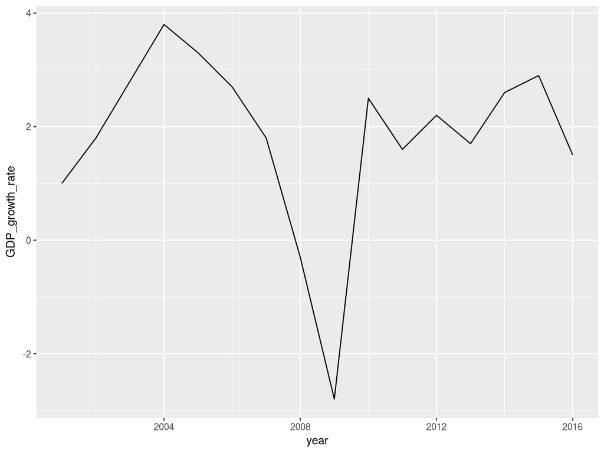

```r
#install.packages('bea.R')
library(bea.R)

#install.packages("striprtf")
library(striprtf)

#read in API access key
beaKey <- read_rtf(file.path(dir_M,'git-annex/neprep/keys/BureauofEconomicAnalysis.rtf'))

## use beaParams to find the parameters the API call needs to get the Regional GDP data we want.
#beaParams(beaKey, "RegionalProduct") #this function lists the necessary parameters to feed into the beaGet function

beaSpecs <- list(
    'UserID' = beaKey ,
    'Method' = 'GetData',
    'datasetname' = 'NIPA', #name of the table
    'Frequency' = 'A',      #reported annually
    'TableName' = 'T10101', #this table is GDP growth rate
    'Year' = 'ALL'
);

us_gdp <- beaGet(beaSpecs) %>%
  filter(LineDescription == "Gross domestic product") %>%
  select(-TableID, -TableName, -SeriesCode, -LineNumber, -LineDescription, -METRIC_NAME, -CL_UNIT, -UNIT_MULT) %>%
  gather(key = "Year", value  = "GDP_growth_rate") %>%
  separate(Year, c('X', 'Year'), sep="_") %>%
  select(-X) %>%
  filter(Year > 2000) %>%
  mutate(year = as.numeric(Year))

ggplot(us_gdp, aes(x = year, y = GDP_growth_rate)) +
  geom_line()
```

```r
write.csv(us_gdp, file = file.path(dir_calc, "layers/eco_usa_gdp.csv"))
```

# Results

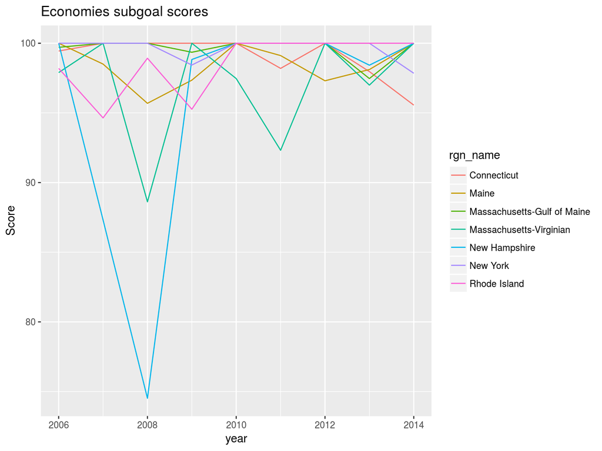

```r
  #compare regional gdp growth to nationwide average
  gdp_score <- cst_gdp %>%
    left_join(us_gdp) %>%
    mutate(GDP_growth_rate = GDP_growth_rate/100 + 1,
           score = ifelse(cst_chg > GDP_growth_rate, 1, cst_chg/GDP_growth_rate)*100) %>%
    select(rgn_id, year, score) %>%
    left_join(rgn_data)

    ggplot(gdp_score, aes(x = year, y = score, color = rgn_name)) +
    geom_line() +
      ylab("Score")+
      ggtitle("Economies subgoal scores")
```

# References

National Ocean Economics Program. Ocean Economic Data by Sector & Industry., ONLINE. 2012. Available: http://www.OceanEconomics.org/Market/oceanEcon.asp [3 October 2017]